# BERD tutorial analysis - WGCNA

Ellen C. Francis

May 14 2025

*Funding: NICHD R00108272*

# # Code chunk 1 #

```r
setwd("C:/Users/ef447/OneDrive - Rutgers University/DOCUMENTS/TALKS/BERD/Tutorial")
getwd();
```

```
## [1] "C:/Users/ef447/OneDrive - Rutgers University/DOCUMENTS/TALKS/BERD/Tutorial"
```

```r
# If necessary, change the path below to the directory where the data files are stored.
# "." means current directory. On Windows use a forward slash / instead of the usual \.
workingDir = ".";
setwd(workingDir);
# Load the WGCNA package
library(WGCNA)

# Load data wrangling package
library(tidyverse)
library(tibble)

#load packages for association testing
library(CorLevelPlot)
#devtools::install_github("kevinblighe/CorLevelPlot")
library(rstatix)
library(reshape2)
#install.packages("ggstatsplot")
library(ggstatsplot)

# The following setting is important, do not omit.
options(stringsAsFactors = FALSE);
# Allow multi-threading within WGCNA. At present this call is necessary.
# Any error here may be ignored but you may want to update WGCNA if you see one.
# Caution: skip this line if you run RStudio or other third-party R environments.
# See note above.
enableWGCNAThreads()
```

```
## Allowing parallel execution with up to 7 working processes.
```

```r
########load metabolomics data########
# (technical filtering has been applied to this data)
bd1_resultsd4 <- read.csv("bd1_resultsd4.csv")
bd1_resultsd4 %>% select(-X) -> bd1_resultsd4 #remove random x variable
as_tibble(bd1_resultsd4)
```

```
## # A tibble: 2,316 × 1,066
##    RT_mass          PZDa_S_85 PZDa_S_88 PZDa_S_91 PZDa_S_93 PZDa_S_94 PZDa_S_95
##    <chr>                <dbl>     <dbl>     <dbl>     <dbl>     <dbl>     <dbl>
##  1 0.98_246.0843n       8911.     6283.     6770.    10984. 10194.       11369.
##  2 0.58_419.8265n     120003.   152061.    81519.   112836. 99367.      110255.
##  3 13.88_496.3606n     92246.    80386.    61510.    81880. 92527.       61615.
##  4 15.10_1207.8606n    84049.    62840.    52318.    57635. 53786.       37394.
##  5 0.58_427.8082n      63991.    47761.    58627.    70184. 48429.       46057.
##  6 0.58_613.6563n      74855.    41628.    53751.    54224. 45097.       24597.
##  7 0.58_301.8182n      52380.    27974.    65844.    52936. 32318.       63798.
##  8 0.58_535.7438n      67731.    53495.    47683.    60587. 50775.       25172.
##  9 6.85_866.4993n      24675.     6781.     9872.      860.     0.828     7555.
## 10 7.23_972.4685n      39655.     5402.    10223.      466.   653.        6728.
## # ℹ 2,306 more rows
## # ℹ 1,059 more variables: PZDa_S_101 <dbl>, PZDa_S_103 <dbl>, PZDa_S_105 <dbl>,
## #   PZDa_S_106 <dbl>, PZDa_S_109 <dbl>, PZDa_S_111 <dbl>, PZDa_S_113 <dbl>,
## #   PZDa_S_115 <dbl>, PZDa_S_116 <dbl>, PZDa_S_117 <dbl>, PZDa_S_118 <dbl>,
## #   PZDa_S_119 <dbl>, PZDa_S_122 <dbl>, PZDa_S_123 <dbl>, PZDa_S_125 <dbl>,
## #   PZDa_S_126 <dbl>, PZDa_S_127 <dbl>, PZDa_S_128 <dbl>, PZDa_S_130 <dbl>,
## #   PZDa_S_132 <dbl>, PZDa_S_134 <dbl>, PZDa_S_136 <dbl>, PZDa_S_137 <dbl>, …
```

#pivot and transform data so that it conforms to WGCNA rules #Samples in Rows and Metabolites in Columns

```r
datExpr <- bd1_resultsd4 %>% pivot_longer(!RT_mass, names_to="sample_name") %>%
  pivot_wider(names_from="RT_mass", values_from="value") %>%
  column_to_rownames(var = "sample_name") # this is the full metabolomics dataset with all the samples
as_tibble(datExpr)
```

```
## # A tibble: 1,065 × 2,316
##    `0.98_246.0843n` `0.58_419.8265n` `13.88_496.3606n` `15.10_1207.8606n`
##               <dbl>            <dbl>             <dbl>              <dbl>
##  1            8911.          120003.            92246.             84049.
##  2            6283.          152061.            80386.             62840.
##  3            6770.           81519.            61510.             52318.
##  4           10984.          112836.            81880.             57635.
##  5           10194.           99367.            92527.             53786.
##  6           11369.          110255.            61615.             37394.
##  7            9419.           93236.            67732.             55513.
##  8            8281.          143459.            63555.             53803.
##  9            8152.          160727.           115426.             62953.
## 10           14682.          132265.            89522.             72914.
## # ℹ 1,055 more rows
## # ℹ 2,312 more variables: `0.58_427.8082n` <dbl>, `0.58_613.6563n` <dbl>,
## #   `0.58_301.8182n` <dbl>, `0.58_535.7438n` <dbl>, `6.85_866.4993n` <dbl>,
## #   `7.23_972.4685n` <dbl>, `16.51_470.3868n` <dbl>, `0.58_593.7024n` <dbl>,
## #   `1.72_320.0577n` <dbl>, `1.10_560.0420n` <dbl>, `13.33_526.3713n` <dbl>,
## #   `0.58_555.6979n` <dbl>, `10.22_360.1928n` <dbl>, `0.58_429.8052n` <dbl>,
## #   `7.01_1070.5059n` <dbl>, `11.19_528.3508n` <dbl>, `6.03_936.4529n` <dbl>, …
```

```r
#names(df1) # to get the column names
dim(datExpr) #to get the dimensions
```

```
## [1] 1065 2316
```

**QC.**

**Identify potential outliers.**

**Table of WGNCA function to detect outlier “genes”/metabolites and outlier samples.**

All metabolites and samples ok so we move to normalization

```r
gsg <- goodSamplesGenes(datExpr)
```

```
##  Flagging genes and samples with too many missing values...
##   ..step 1
```

```r
summary(gsg)
```

```
##             Length Class  Mode
## goodGenes   2316   -none- logical
## goodSamples 1065   -none- logical
## allOK          1   -none- logical
```

```r
gsg$allOK
```

```
## [1] TRUE
```

```r
#look to see how many are outliers. All metabolites and samples ok.
table(gsg$goodGenes)
```

```
##
## TRUE
## 2316
```

```r
table(gsg$goodSamples)
```

```
##
## TRUE
## 1065
```

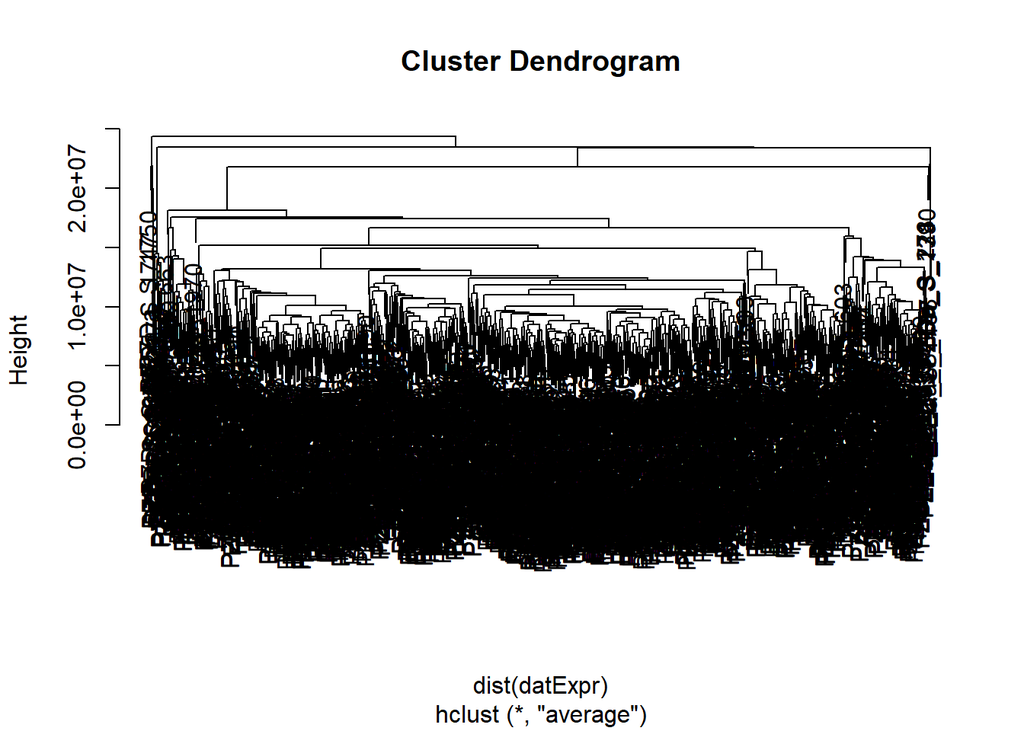

```r
#detect outliers using hierarchical clustering

htree <- hclust(dist(datExpr), method ="average")
plot(htree) # potentially some outliers
```

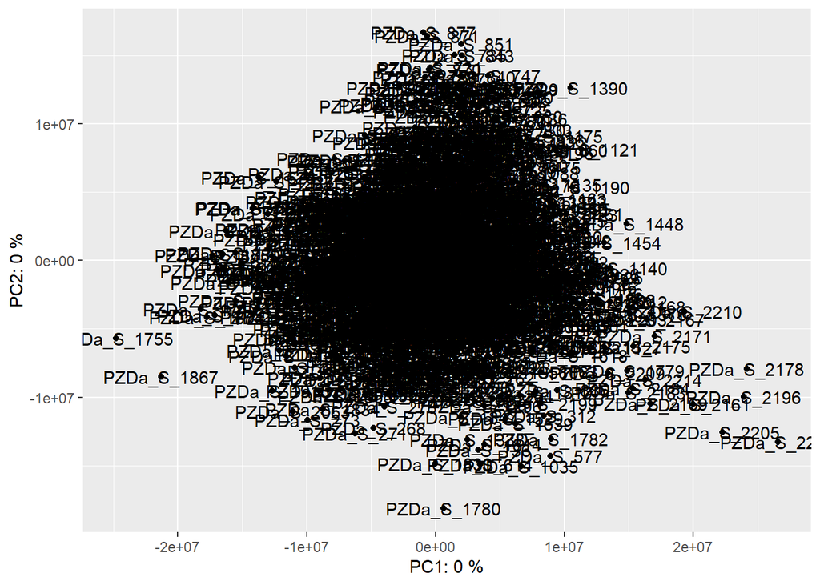

```r
# detect outliers using pca
pca <- prcomp(datExpr)
pca.dat <- pca$x
pca.var <- pca$sdev^2
pca.var.percent <- round(pca.var/sum(pca.var*100), digits =2)

pca.dat <- as.data.frame(pca.dat)

ggplot(pca.dat, aes(PC1, PC2)) +
  geom_point() +
  geom_text(label = rownames(pca.dat)) +
  labs(x = paste0('PC1: ', pca.var.percent[1], ' %'),
       y = paste0('PC2: ', pca.var.percent[2], ' %'))
```

```r
samples.excluded <- c("PZDa_S_603", "PZDa_S_1390", "PZDa_S_2118")  #Possibly exclude
```

We could exclude three samples because they look like outliers “PZDa_S_603”, “PZDa_S_1390”, “PZDa_S_2118”. Exclusion of these does not change the results

# # Code chunk 2 #

```r
powers = c(c(1:10), seq(from = 12, to=20, by=2))
# Call the network topology analysis function
sft = pickSoftThreshold(datExpr, powerVector = powers, verbose = 5)
```

```
## pickSoftThreshold: will use block size 2316.
##  pickSoftThreshold: calculating connectivity for given powers...
##    ..working on genes 1 through 2316 of 2316
##    Power SFT.R.sq  slope truncated.R.sq mean.k. median.k. max.k.
## 1      1    0.015 -0.167          0.811  358.00   338.000  741.0
## 2      2    0.573 -0.752          0.881  108.00    87.400  322.0
## 3      3    0.929 -0.999          0.975   48.20    33.600  186.0
## 4      4    0.937 -1.180          0.930   27.40    14.900  138.0
## 5      5    0.929 -1.250          0.909   18.20     8.130  115.0
## 6      6    0.928 -1.280          0.907   13.30     5.110   98.6
## 7      7    0.928 -1.280          0.910   10.30     3.570   86.6
## 8      8    0.927 -1.290          0.910    8.34     2.680   76.9
## 9      9    0.942 -1.300          0.927    6.93     2.010   68.9
## 10    10    0.961 -1.310          0.950    5.87     1.610   62.0
## 11    12    0.966 -1.320          0.956    4.38     1.100   51.0
## 12    14    0.986 -1.350          0.983    3.41     0.820   42.4
## 13    16    0.974 -1.390          0.973    2.73     0.621   35.7
## 14    18    0.961 -1.400          0.961    2.23     0.464   30.3
## 15    20    0.943 -1.430          0.947    1.86     0.348   26.0
```

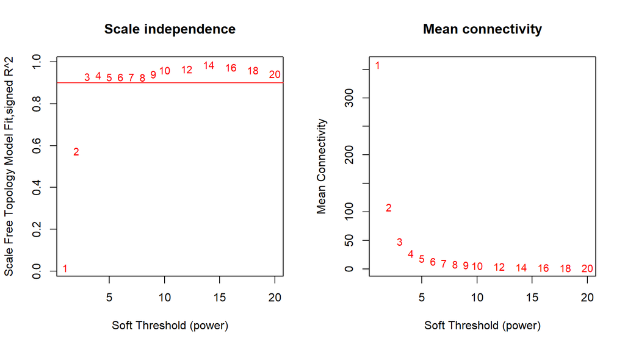

```r
# Plot the results:
par(mfrow = c(1,2));
cex1 = 0.9;
# Scale-free topology fit index as a function of the soft-thresholding power
plot(sft$fitIndices[,1], -sign(sft$fitIndices[,3])*sft$fitIndices[,2],
     xlab="Soft Threshold (power)",ylab="Scale Free Topology Model Fit,signed R^2",type="n",
     main = paste("Scale independence"));
text(sft$fitIndices[,1], -sign(sft$fitIndices[,3])*sft$fitIndices[,2],
     labels=powers,cex=cex1,col="red");
# this line corresponds to using an R^2 cut-off of h
abline(h=0.90,col="red")
# Mean connectivity as a function of the soft-thresholding power
plot(sft$fitIndices[,1], sft$fitIndices[,5],
     xlab="Soft Threshold (power)",ylab="Mean Connectivity", type="n",
     main = paste("Mean connectivity"))
text(sft$fitIndices[,1], sft$fitIndices[,5], labels=powers, cex=cex1,col="red")
```

If R² is consistently below 0.8: Your network may not be scale-free, suggesting you might need to try a different power range or consider whether WGCNA is appropriate for this dataset.

Low Mean Connectivity: If mean connectivity is very low, your modules might be poorly defined, indicating a need for a lower power.

*CONNECTIVITY - High Mean Connectivity: Suggests that many nodes are interconnected, forming dense modules that are likely to reflect real biological networks. - Low Mean Connectivity: Indicates that most nodes are weakly connected, potentially forming sparse or poorly defined modules, which can make it difficult to identify biologically meaningful clusters.

*POWER - Higher Power: Makes the adjacency matrix more binary (sharper separation of strong vs. weak connections), reducing overall connectivity. - Lower Power: Produces a more interconnected network, increasing overall connectivity.

# # Code chunk 3 #

```r
softPower = 6;
adjacency = adjacency(datExpr, power = softPower);
```

# # Code chunk 4 #

```r
TOM = TOMsimilarity(adjacency);
```

```
## ..connectivity..
## ..matrix multiplication (system BLAS)..
## ..normalization..
## ..done.
```

```r
dissTOM = 1-TOM
```

# # Code chunk 5 #

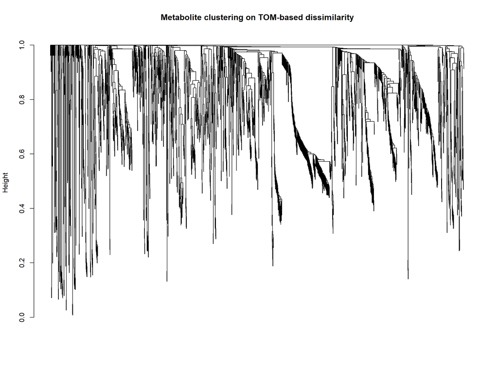

```r
geneTree = hclust(as.dist(dissTOM), method = "average");
# Plot the resulting clustering tree (dendrogram)
plot(geneTree, xlab="", sub="", main = "Metabolite clustering on TOM-based dissimilarity",
     labels = FALSE, hang = 0.04);
```

# # Code chunk 6 #

```r
#We like large modules, so we set the minimum module size relatively high:
minModuleSize = 30;
# Module identification using dynamic tree cut:
dynamicMods = cutreeDynamic(dendro = geneTree, distM = dissTOM,
                deepSplit = 2, pamRespectsDendro = FALSE,
                minClusterSize = minModuleSize);
```

```
##  ..cutHeight not given, setting it to 0.994  ===>  99% of the (truncated) height range in dendro.
##  ..done.
```

```r
table(dynamicMods)
```

```
## dynamicMods
##   0   1   2   3   4   5   6   7   8   9  10  11  12
## 586 354 348 178 175 159  98  83  82  82  68  60  43
```

# # Code chunk 7 #

```r
dynamicColors = labels2colors(dynamicMods)
table(dynamicColors)
```

```
## dynamicColors
##       black        blue       brown       green greenyellow        grey
##          83         348         178         159          60         586
##     magenta        pink      purple         red         tan   turquoise
##          82          82          68          98          43         354
##      yellow
##         175
```